# Exam 2

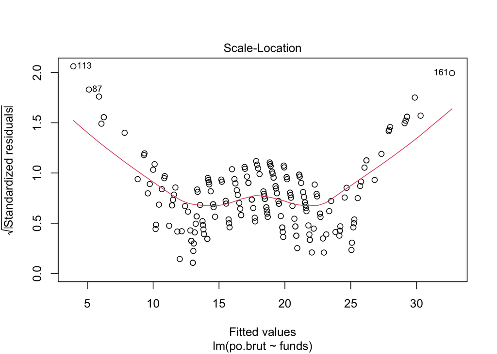

```r
plot(reg.output, 3)
```

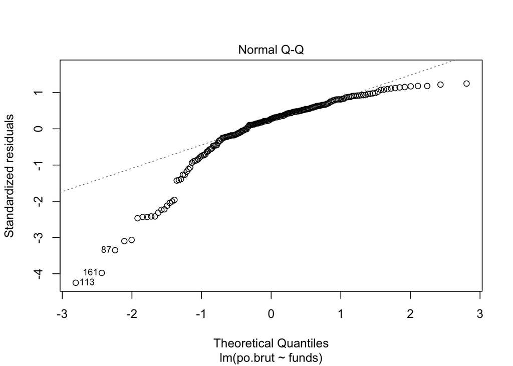

```r
plot(reg.output, 2)
```

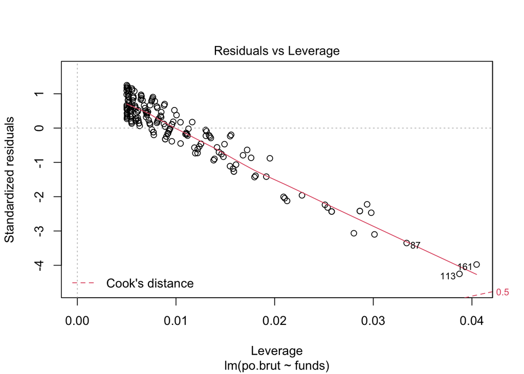

```r
plot(reg.output, 5)
```

5. Answer the question of interest based on your analysis.

**Based on my analysis, none of the assumptions of a linear regression model were satisfied, thus why the linear regression model was not very useful. In fact, I was surprised with the results, but the failed assumptions explains why this model was not the best model to analze the data.**

# Problem 3: Data ethics (10 points)

Describe the dataset. Considering our lecture on data ethics, what concerns do you have about the dataset? Once you perform your analysis to answer the question of interest using this dataset, what concerns might you have about the results?

**I believe that there is not enough consideration of the racial biases within policing. The data only accounts for two distinct factors with no acknowledgement of several, oustanding factors such as location of the police departments, races of the individuals involved in the instances of police brutality, etc. The issue of police brutality is not merely an economic issue Essentially, the data set does not reflect the real social, racial, and economic implications of policing, creating an incomplete dataset and therefore weak conclusion. .**